# *spatialHeatmap*: Visualizing Spatial Assays in Anatomical Images and Network Graphs

Authors: Jianhai Zhang, Bing Yang, Wolf B. Frommer, Julia Bailey-Serres and Thomas Girke

Last update: 24 April, 2020

# 1 Introduction

## 1.1 Motivation

The *spatialHeatmap* package provides functionalities for visualizing cell-, tissue- and organ-specific data of biological assays by coloring the corresponding spatial features defined in anatomical images according to a numeric color key. The color scheme used to represent the assay values can be customized by the user. This core functionality is called a *spatial heatmap* plot. It is enhanced with nearest neighbor visualization tools for groups of measured items (*e.g.* gene modules) sharing related abundance profiles, including matrix heatmaps combined with hierarchical clustering dendrograms and network representations. The functionalities of *spatialHeatmap* can be used either in a command-driven mode from within R or a graphical user interface (GUI) provided by a Shiny App that is also part of this package. While the R-based mode provides flexibility to customize and automate analysis routines, the Shiny App includes a variety of convenience features that will appeal to many biologists. Moreover, the Shiny App has been designed to work on both local computers as well as server-based deployments (*e.g.* cloud-based or custom servers) that can be accessed remotely as a centralized web service for using *spatialHeatmap’s* functionalities with community and/or private data.

[ThG-Comment 1: Please add here an overview illustration (“visual abstract”) of the entire package that outlines all its core functionalities in one figure. Similar to Fig 1 and Fig 2 in the *signatureSearch* vignette [here](https://bit.ly/2RGmUON). In your case, the package design illustration (from Fig 2) could go into the same figure. To keep it simple and reusable, please create this illustration in a Google Drawing that you share with me. This way we can jointly edit it, and export to SVG or PNG as needed. Please take your time to create a quality illustration for this purpose that both looks professional and is informative too. The intent of this illustration is to use it in various places, e.g. slide shows, posters, vignette and paper.]

As anatomical images the package supports both tissue maps from public repositories and custom images provided by the user. In general any type of image can be used as long as it can be provided in SVG (Scalable Vector Graphics) format, where the corresponding spatial features have been defined (see aSVG below). The numeric values plotted onto a spatial heatmap are usually quantitative measurements from a wide range of profiling technologies, such as microarrays, next generation sequencing (*e.g.* RNA-Seq and scRNA-Seq), proteomics, metabolomics, or many other small- or large-scale experiments. For convenience, several preprocessing and normalization methods for the most common use cases are included that support raw and/or preprocessed data. Currently, the main application domains of the *spatialHeatmap* package are numeric data sets and spatially mapped images from biological and biomedical areas. Moreover, the package has been designed to also work with many other spatial data types, such a population data plotted onto geographic maps. This high level of flexibility is one of the unique features of *spatialHeatmap*. Related software tools for biological applications in this field are largely based on pure web applications (Winter et al. 2007; Waese et al. 2017) or local tools (Maag 2018; Muschelli, Sweeney, and Crainiceanu 2014) that typically lack customization functionalities. These restrictions limit users to utilizing pre-existing expression data and/or fixed sets of anatomical image collections. To close this gap for biological use cases, we have developed *spatialHeatmap* as a generic R/Bioconductor package for plotting quantitative values onto any type of spatially mapped images in a programmable environment and/or in an intuitive to use GUI application.

## 1.2 Design

The core feature of `spatialHeatmap` is to map the assay values (*e.g.* gene expression data) of one or many items (*e.g.* genes) measured under different conditions in form of numerically graded colors onto the corresponding cell types or tissues represented in a chosen SVG image. In the gene profiling field, this feature supports comparisons of the expression values among multiple genes by plotting their spatial heatmaps next to each other. Similarly, one can display the expression values of a single or multiple genes across multiple conditions in the same plot. This level of flexibility is very efficient for visualizing complicated expression patterns across genes, cell types and conditions. In case of more complex anatomical images composed of overlapping multiple layer tissues, it is important to visually expose the tissue layer of interest in the plots. To address this, several default and customizable layer viewing options are provided. They allow to hide features in the top layers by making them transparent in order to expose features below them. This transparency viewing feature is highlighted below in the mouse example.

To maximize reusability and extensibility, the package organizes large-scale omics assay data along with the associated experimental design information in a `SummarizedExperiment` object. The latter is one of the core S4 classes within the Bioconductor ecosystem that has been widely adapted by many other software packages dealing with gene-, protein- and metabolite-level profiling data (Morgan et al. 2018). In case of gene expression data, the `assays` slot of the `SummarizedExperiment` container is populated with a gene expression matrix, where the rows and columns represent the genes and tissue/conditions, respectively, while the `colData` slot contains replicate information. The tissues and/or cell type information in the object maps via `colData` to the corresponding features in the SVG images using unique identifiers for the spatial features (*e.g.* tissues or cell types). This allows to color the features of interest in an SVG image according to the numeric data stored in a `SummarizedExperiment` object. Details about how to properly format both the SVG images and the associated expression data are provided in the Formatting Requirements section of this vignette.

## 1.3 Terminology

Spatial heatmaps are images where colors encode numeric values in features of any shape. For plotting spatial heatmaps, Scalable Vector Graphics (SVG) has been chosen as image format since it is a flexible and widely adapted vector graphics format that provides many advantages for computationally embedding numerical and other information in images. SVG is based on XML formatted text describing all components present in images, including lines, shapes and colors. In case of biological images suitable for spatial heatmaps, the shapes often represent anatomical or cell structures. To assign colors to specific features in spatial heatmaps, *annotated SVG* (aSVG) files are used where the shapes of interest are labeled according to certain conventions so that they can be addressed and colored programmatically. SVGs and aSVGs of anatomical structures can be downloaded from many sources including the repositories described below. Alternatively, users can generate them themselves with vector graphics software such as [Inkscape](https://inkscape.org/). Typically, in aSVGs one or more shapes of a feature of interest, such as the cell shapes of an organ, are grouped together by a common feature identifier. Via these group identifiers one or many feature types can be colored simultaneously in an aSVG according to biological experiments assaying the corresponding feature types with the required spatial resolution. Correct assignment of image features and assay results is assured by using for both the same feature identifiers. The color gradient used to visually represent the numeric assay values is controlled by a color gradient parameter. To visually interpret the meaning of the colors, the corresponding color key can be included in the spatial heatmap plots. The formatting details for properly annotating both aSVG images and assay data are provided in the Supplement Section of this vignette.

## 1.4 Data Repositories

If not generated by the user, spatial heatmaps can be generated with data downloaded from various public repositories. This includes gene, protein and metabolic profiling data from databases, such as GEO, BAR and EBI. A particularly useful resource, when working with `spatialHeatmap`, is the Expression Atlas from EMBL-EBI (Papatheodorou et al. 2018). This online service contains both assay and anatomical image data. Its assays data include mRNA and protein profiling experiments for different species, tissues and conditions. The corresponding anatomical image collections are also provided for a wide range of species including animals and plants. In `spatialHeatmap` several import functions are provided to work with the expression and images from the Expression Atlas directly. To make the SVG images from the Expression Atlas fully compatible with `spatialHeatmap`, slight modifications had to be introduced in their SVG files. The fully annotated and ready-to-use aSVG image collection of the Expression Atlas is available in the SVG repository of this package. Apart from posting future image updates from the Expression Atlas and other public sources, the same SVG repository is used to deposit custom images developed by this project and/or those contributed by users.

## 1.5 Tutorial Overview

The following sections of this vignette showcase the most important functionalities of the `spatialHeatmap` package using as first example a simple to understand toy data set, and then more complex mRNA profiling data from the Expression Atlas. First, spatial heatmap plots are generated for both the toy and mRNA expression data. The latter include gene expression data sets from RNA-Seq and microarray experiments of Human Brain, Mouse Organs, Chicken Organs, and Arabidopsis Shoots. The first three are RNA-Seq data from the [Expression Atlas](https://www.ebi.ac.uk/gxa/home) and the last one is a microarray data set from [GEO](https://www.ncbi.nlm.nih.gov/geo/). Second, gene context visualization features are introduced, which facilitate the visualization of gene modules sharing similar expression patterns. This includes the visualization of hierarchical clustering results with traditional matrix heatmaps (Matrix Heatmap) as well co-expression network plots (Network). Third, an overview of the corresponding Shiny App is presented that provides access to the same functionalities as the R functions, but executes them in an interactive environment (Chang et al., n.d.; Chang and Borges Ribeiro 2018). Fourth, more advanced features for plotting customized spatial heatmaps are introduced using the Human Brain data set as an example.

# 2 Getting Started

## 2.1 Installation

The `spatialHeatmap` package should be installed from an R (version $\ge$ 3.6) session with the `BiocManager::install` command.

```r
if (!requireNamespace("BiocManager", quietly = TRUE))
    install.packages("BiocManager")
BiocManager::install("spatialHeatmap")
```

## 2.2 Load Packages and Documentation

Next, the packages required for running the sample code in this vignette need to be loaded.

```r
library(spatialHeatmap); library(SummarizedExperiment); library(ExpressionAtlas); library(GEOquery)
```

The following lists the vignette(s) of this package in an HTML browser. Clicking the corresponding name will open this vignette.

```r
browseVignettes('spatialHeatmap')
```

# 3 Spatial Heatmaps

[ThG-Comment 2: how can the user find out what features are defined (mapped) in the existing SVG images provided by your SVG collection, or the one from Expression Atlas? A very common use case would be that the user has generated some cell/tissue specific expression data, and then wants to map it to an existing mapped SVG. How can they find out what SVGs contain the features they have data for, so that they can properly set up their expression data for plotting and choose the appropriate SVG images rather than generating their own. Shouldn’t each SVG be accompanied with a feature table, or an R function provided that returns this info from a mapped SVG by parsing it? This would be an obvious utility reviewers and user will ask for in a package that is supposed to provide a high level of flexibilty and reusability, and I don’t think it would be hard to address this important need.]

## 3.1 Toy Example

Spatial heatmaps are plotted with the `spatial_hm` function. To provide a quick and transparent overview how these plots are generated, the following uses a generalized toy example where a vector of random numeric values is generated that are used to color the corresponding features in an aSVG image. The image chosen for this example is from the human brain. The latter has been included in this package for testing purposes. The path to the file of this image on a user’s system, where `spatialHeatmap` is installed, can be obtained with the `system.file` function.

```r
svg.hum <- system.file("extdata/shinyApp/example", "homo_sapiens.brain.svg", package="spatialHeatmap")
```

The `returnSVGFeatures` function can be used to return the feature names present in an aSVG image.

```r
fnames <- retrunSVGFeatures("...")
fnames
```

A small numeric toy vector is generated, where the data slot contains five numbers and its name slot is populated with the feature names obtained from the aSVG image. Note, the numbers are mapped to features via names matching among the numeric vector and the aSVG, respectively. Accordingly, only numbers and features with matching name counterparts can be colored in the aSVG image. Entries without name matches are indicated by a message printed to the R console. This behavior can be turned off with `verbose=FALSE` in the corresponding function call. In addition, a summary of the numeric assay to feature mappings is stored in the result object returned by the `spatial_hm` function.

```r
my_vec <- sample(1:100, length(unique(fnames)))
names(my_vec) <- unique(fnames)
```

Next, the spatial heatmap is plotted with the `spatial_hm` function. Internally, the numbers in `my_vec` are translated to colors based on the color key assigned to the `col.com` argument, and then painted onto the corresponding features in the aSVG image (here path `svg.hum`).

```r
spatial_hm(svg.path=svg.hum, se=my_vec, col.com=c("yellow", "blue", "purple"))
```

[ThG-Comment 3: Jianhai, please add a section that accomplishes what is described in the above text and code chunks. When done the corresponding functional code chunks should be functional and evaluated in the vignette. This will help to give the user a quick code-based intro into the core functionalities of the spatial_hm function without requiring too much background knowledge about expression data and other details. Note, this section overlaps with the comment #2, since it requires some basic functionality to extract feature names from pre-annotated SVGs.]

## 3.2 Human Brain

This subsection introduces how to find cell- and tissue-specific assay data in the Expression Atlas database. After choosing a gene expression experiment, the data is downloaded directly into a user’s R session and preprocessed. Subsequently, the processed expression values of genes selected by users are plotted onto a chosen aSVG image. In this case, the query and download functionalities of expression data are provided by functionalities of the `ExpressionAtlas` package.

The following example searches the Expression Atlas for expression data derived from specific tissues and species of interest, here *‘cerebellum’* and *‘Homo sapiens’*, respectively.

```r
all.hum <- searchAtlasExperiments(properties="cerebellum", species="Homo sapiens")
```

The search result is stored in a `DataFrame` containing 13 accessions matching the above query. For the following sample code, the accession ‘[E-GEOD-67196](https://www.ebi.ac.uk/arrayexpress/experiments/E-GEOD-67196/)’ from Prudencio *et al.* (2015) has been chosen, which corresponds to an RNA-Seq profiling experiment of *‘cerebellum’* and *‘frontal cortex’* brain tissue from patients with amyotrophic lateral sclerosis (ALS). Details about the corresponding record can be returned as follows.

```r
all.hum[2, ]
```

```
## DataFrame with 1 row and 4 columns
##      Accession      Species                  Type
##    <character>  <character>           <character>
## 1 E-GEOD-67196 Homo sapiens RNA-seq of coding RNA
##                                                                                                                                   Title
##                                                                                                                             <character>
## 1 Transcription profiling by high throughput sequencing of cerebellum and frontal cortex from patients of amyotrophic lateral sclerosis
```

The `getAtlasData` function allows to download the chosen RNA-Seq experiment from the Expression Atlas and import it into a `RangedSummarizedExperiment` of a user’s R session.

```r
rse.hum <- getAtlasData('E-GEOD-67196')[[1]][[1]]
```

```
##  ftp://ftp.ebi.ac.uk/pub/databases/microarray/data/atlas/experiments/E-GEOD-67196/E-GEOD-67196-atlasExperimentSummary.Rdata
```

```
## Successfully downloaded experiment summary object for E-GEOD-67196
```

The design of the downloaded RNA-Seq experiment is described in the `colData` slot of `rse.hum`. The following returns only its first five rows and columns.

```r
colData(rse.hum)[1:5, 1:5]
```

```
## DataFrame with 5 rows and 5 columns
##            AtlasAssayGroup     organism   individual  organism_part
##                <character>  <character>  <character>    <character>
## SRR1927019              g1 Homo sapiens  individual1     cerebellum
## SRR1927020              g2 Homo sapiens  individual1 frontal cortex
## SRR1927021              g1 Homo sapiens  individual2     cerebellum
## SRR1927022              g2 Homo sapiens  individual2 frontal cortex
## SRR1927023              g1 Homo sapiens individual34     cerebellum
##                                  disease
##                              <character>
## SRR1927019 amyotrophic lateral sclerosis
## SRR1927020 amyotrophic lateral sclerosis
## SRR1927021 amyotrophic lateral sclerosis
## SRR1927022 amyotrophic lateral sclerosis
## SRR1927023 amyotrophic lateral sclerosis
```

For downstream plotting purposes it can be desirable to shorten the text in certain columns of `colData`. This way one can use the source data for including ‘pretty’ sample names in columns and legends of all downstream tables and plots, respectively, in an automated and reproducible manner. To achieve this, the following example imports a ‘targets’ file that can be maintained by the user and is used to replace the text in the `colData` slot with the shortened version suitable for column titles and legends. This targets file utility is particularly useful for data sets requiring custom annotations. Additional details for generating and using targets files in `spatialHeatmap` are provided in the Supplement of this vignette.

```r
hum.pa <- system.file('extdata/shinyApp/example/target_human.txt', package='spatialHeatmap')
target.hum <- read.table(hum.pa, header=TRUE, row.names=1, sep='\t')
colData(rse.hum) <- DataFrame(target.hum)
```

A slice of the simplified `colData` object is shown below, where the `disease` column contains now shorter labels than in the original data set.

```r
colData(rse.hum)[c(1:3, 41:42), 4:5]
```

```
## DataFrame with 5 rows and 2 columns
##             organism_part     disease
##               <character> <character>
## SRR1927019     cerebellum         ALS
## SRR1927020 frontal_cortex         ALS
## SRR1927021     cerebellum         ALS
## SRR1927059     cerebellum      normal
## SRR1927060 frontal_cortex      normal
```

The actual expression data of the downloaded RNA-Seq experiment is stored in the `assay` slot of `rse.hum`. Since it contains raw count data, it is often beneficial to apply prior to plotting spatial heatmaps basic preprocessing routines. The following shows how to normalize the count data, aggregate replicates and then remove genes with unreliable expression responses.

[ThG-Comment 4: can you please substantially improve the below text in the following preprocessing code step as well as the help files of the corresponding functions. I am not able to follow why and how certain parts are done. For instance, why is ratio used as a normalization method? The final result also doesn’t seem to be log ratios. You need to better describe what you are doing here. Asking readers to look through your code is not appropriate for a package.]

```r
# Normalise.
se.nor.hum <- norm_data(se=rse.hum, method.norm='ratio', data.trans='log2')
```

```
## Normalising: ratio
```

```r
# Aggregate replicates.
se.aggr.hum <- aggr_rep(se=se.nor.hum, sam.factor='organism_part', con.factor='disease', aggr='mean')
# Filter genes with low variance and low counts.
se.fil.hum <- filter_data(se=se.aggr.hum, sam.factor='organism_part', con.factor='disease', pOA=c(0.01, 5), CV=c(0.3, 100), dir=NULL)
```

To inspect the results, the following returns three selected rows of the fully preprocessed data matrix.

```r
assay(se.fil.hum)[733:735, ]
```

|  | cerebellum__ALS | frontal_cortex__ALS | cerebellum__normal | frontal_cortex__normal |
| --- | --- | --- | --- | --- |
| ENSG00000268433 | 5.324064 | 0.3419665 | 3.478074 | 0.1340332 |
| ENSG00000268555 | 5.954572 | 2.6148548 | 4.934974 | 2.0351776 |
| ENSG00000269113 | 7.544417 | 1.7425299 | 6.808402 | 0.9694065 |

The following shows how to download the corresponding pre-annotated aSVG image from the SVG repository of this package.

[ThG-Comment 5: please add here the corresponding but unevaluated code to download the aSVG from your repos. Users want to know how this works.]

As explained in the previous section, the same aSVG image has been included in this package. To meet the requirements for building vignettes in R packages, the following code section uses the packaged instance of the aSVG file rather than downloading it.

```r
svg.hum <- system.file("extdata/shinyApp/example", "homo_sapiens.brain.svg", package="spatialHeatmap")
```

Next, the preprocessed expression values of gene `ENSG00000268433` are plotted onto the corresponding features of the aSVG image depicting the human brain.

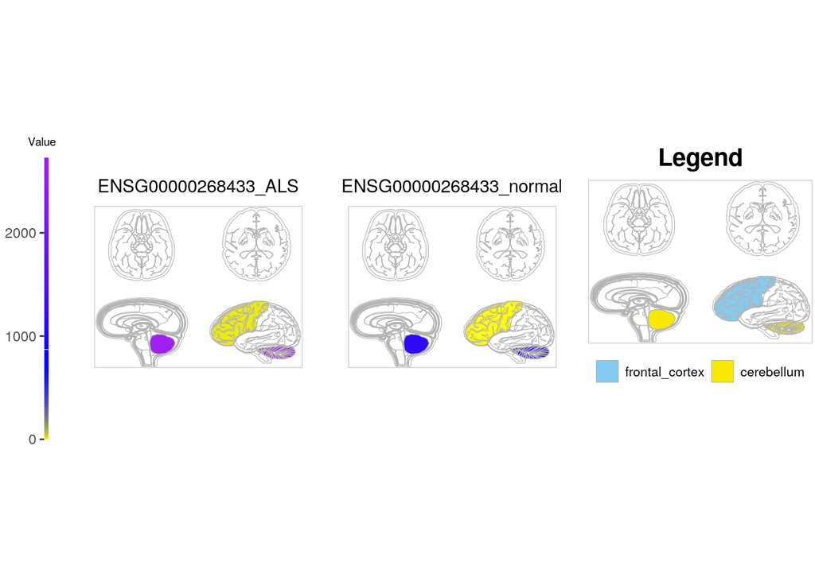

Figure 1 Example of plotting EBI data matrix on the SVG template. Cerebellum and frontal cortex are colored, since they are the only 2 identical tissues between the SVG image and the data matrix.

```r
spatial_hm(svg.path=svg.hum, se=se.fil.hum, ID=c('ENSG00000268433'), col.com=c("yellow", "blue", "purple"), width=1, height=0.4, legend.r=0.5, sub.title.size=11, layout="gene", ncol=2, tis.trans=NULL, sam.legend='identical', line.size=0.2, line.color='grey70', legend.position=c(0.5, -0.15), legend.nrow=1)
```

[ThG-Comment 6: I suggest to include here a table where you summarize all arguments relevant for controlling the output of `spatial_hm` function. This will make it much easier for the user to look up relevant arguments and how to use them.]

[ThG-Comment 7: The paragraphs below have been moved here for now. There is a lot of duplication in this text that needs to be deleted (or hidden via comment tags) and/or merged into other sections where appropriate. Some of the text is certainly important but it often should be used to explain code sections rather than keeping it separate from the code. For instance the first paragraph below should go to a section where you show how to generate multiple target gene plots rather then just describing it in stand-alone text, especially since a summary of this particular example has been given in the intro section already.]

It is able to take mutiple target genes as input. If so, a set of spatial heatmaps for each gene are plotted sequentially and organised on the same page. The `layout` parameter specifies display these spatial heatmaps by genes or by conditions. This feature makes it flexible for users to compare expression profiles of the same gene across conditions or different genes across the same condition. If many conditions are displayed, the `ncol` parameter can be used to adjust the column number in the layout to achieve optimal dispaly.

In the case of tissues existing in multiple layers, some tissues might be covered and invisible in the spatial heatmaps. In this case, the `tis.trans` parameter can be used to set the front tissues transparent. Then the covered tissues will be visible, a representative example of which is shown in Figure 2.

In the legend plot, if too many tissues are included, the legends might occupy too much space and lead to main plot squeezed. To overcome this issue, the `sam.legend` parameter is developed to allows users to only show selected tissues in the legend, and the default “identical” only shows the colored tissues.

Moreover, too many tissues might affect the visual effects due to the messy polygon outlines. The `line.size` and `line.color` parameters are used to adjust the thickness and color of polygon outlines respectively and thus can enhance the visualisation.

## 3.3 Mouse Organ

This example is based on a mouse data from an RNA-seq study aiming at assessing tissue-specific transcriptome variation across mammals (Merkin et al. 2012), which is from EBI Expression Atlas.

Download “mus_musculus.male.svg” from the SVG repository, and check tissue ids in [Inkscape](https://inkscape.org/). Search for related gene expression matrix with tissue id “heart” and “Mus musculus”, and select “E-MTAB-2801”.

```r
all.mus <- searchAtlasExperiments(properties="heart", species="Mus musculus")
```

```
## Searching for Expression Atlas experiments matching your query ...
```

```
## Query successful.
```

```
## Found 67 experiments matching your query.
```

```r
rse.mus <- getAtlasData('E-MTAB-2801')[[1]][[1]]
```

```
##  ftp://ftp.ebi.ac.uk/pub/databases/microarray/data/atlas/experiments/E-MTAB-2801/E-MTAB-2801-atlasExperimentSummary.Rdata
```

```
## Successfully downloaded experiment summary object for E-MTAB-2801
```

Make a targets file (metadata of replicates of tissues and conditions) for the data matrix, which is available in this package.

```r
pa.mus <- system.file('extdata/shinyApp/example/target_mouse.txt', package='spatialHeatmap')
target.mus <- read.table(pa.mus, header=TRUE, row.names=1, sep='\t')
colData(rse.mus) <- DataFrame(target.mus)
```

Pro-process the raw count matrix: normalise, aggregate, filter. Genes with expression values larger than 5 in at least 1% of all samples (pOA=c(0.01, 5)), and with coefficient of variance (CV) between 0.60 and 100 (CV=c(0.6, 100)) are retained.

```r
# Normalise.
se.nor.mus <- norm_data(se=rse.mus, method.norm='ratio', data.trans='log2')
```

```
## Normalising: ratio
```

```r
# Aggregate replicates.
se.aggr.mus <- aggr_rep(se=se.nor.mus, sam.factor='organism_part', con.factor='strain', aggr='mean')
# Filter genes with low variance and low counts.
se.fil.mus <- filter_data(se=se.aggr.mus, sam.factor='organism_part', con.factor='strain', pOA=c(0.01, 5), CV=c(0.6, 100), dir=NULL)
```

The SVG image is formatted and is available in this package.

```r
svg.mus <- system.file("extdata/shinyApp/example", "mus_musculus.male.svg", package="spatialHeatmap")
```

Plot spatial heatmaps.

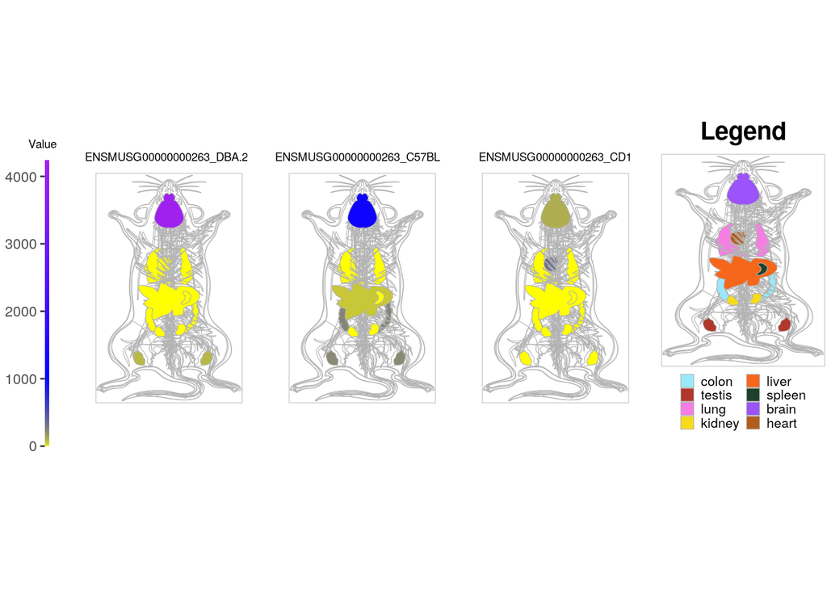

Figure 2 Mouse organ spatial heatmap. This is a multiple-layer image and skeletal.muscle is set transparent to exposed lung and heart.

This is a typical example to demonstrate the usage of `tis.trans` parameter, since this mouse organ image includes tissues in multiple layers and skelectal muscle covers lung and heart. In Figure 2, skelectal muscle is set transparent by `tis.trans='skeletal.muscle'` so that lung and heart are exposed. Users can try setting `tis.trans=NULL` to see the difference.

## 3.4 Chicken Organ

In this example, the data come from developments of 7 chicken organs under 9 time points (Cardoso-Moreira et al. 2019), which is an RNA-seq analysis and available in EBI Expression Atlas.

Download “gallus_gallus.svg” from the SVG repository and check tissue ids in [Inkscape](https://inkscape.org/). Search for related gene expression matrix with key word “gallus”, and select “E-MTAB-6769”.

```r
all.chk <- searchAtlasExperiments(properties="", species="gallus")
```

```
## Searching for Expression Atlas experiments matching your query ...
```

```
## Query successful.
```

```
## Found 33 experiments matching your query.
```

```r
rse.chk <- getAtlasData('E-MTAB-6769')[[1]][[1]]
```

```
##  ftp://ftp.ebi.ac.uk/pub/databases/microarray/data/atlas/experiments/E-MTAB-6769/E-MTAB-6769-atlasExperimentSummary.Rdata
```

```
## Successfully downloaded experiment summary object for E-MTAB-6769
```

Access the selected data automatically from EBI.

```r
rse.chk <- getAtlasData('E-MTAB-6769')[[1]][[1]]
```

```
##  ftp://ftp.ebi.ac.uk/pub/databases/microarray/data/atlas/experiments/E-MTAB-6769/E-MTAB-6769-atlasExperimentSummary.Rdata
```

```
## Successfully downloaded experiment summary object for E-MTAB-6769
```

Make a targets file (metadata of replicates of tissues and conditions) for the data matrix, which is available in this package.

```r
pa.chk <- system.file('extdata/shinyApp/example/target_chicken.txt', package='spatialHeatmap')
target.chk <- read.table(pa.chk, header=TRUE, row.names=1, sep='\t')
colData(rse.chk) <- DataFrame(target.chk)
```

Pro-process data matrix: normalise, aggregate, filter. Genes with expression values larger than 5 in at least 1% of all samples (pOA=c(0.01, 5)), and with coefficient of variance (CV) between 0.6 and 100 (CV=c(0.6, 100)) are retained.

```r
# Normalise.
se.nor.chk <- norm_data(se=rse.chk, method.norm='ratio', data.trans='log2')
```

```
## Normalising: ratio
```

```r
# Aggregate replicates.
se.aggr.chk <- aggr_rep(se=se.nor.chk, sam.factor='organism_part', con.factor='age', aggr='mean')
# Filter genes with low variance and low counts.
se.fil.chk <- filter_data(se=se.aggr.chk, sam.factor='organism_part', con.factor='age', pOA=c(0.01, 5), CV=c(0.6, 100), dir=NULL)
```

The SVG image is formatted and is available in this package.

```r
svg.chk <- system.file("extdata/shinyApp/example", "gallus_gallus.svg", package="spatialHeatmap")
```

Plot spatial heatmaps.

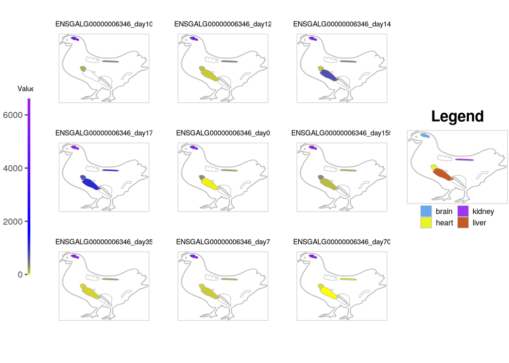

Figure 3 Example of plotting chicken organ spatial heatmaps. Liver in day10 is not plotted since this tissue in day10 in not available in the data matrix.

## 3.5 Arabidopsis Shoot

[GEO](https://www.ncbi.nlm.nih.gov/geo/) is a another well-known public repository of array- and sequence-based data. To demonstrate the use of spatialHeatmap on this resource, the dataset GSE14502 is plotted on a shoot SVG image. This a microarray data from a study of translatome variation of *Arabidopsis thaliana* (Arabidopsis) shoot and root tissues under control and hypoxia conditions (Mustroph et al. 2009), which is accessed through GEOquery (S. Davis and Meltzer 2007).

Download “shoot_final.svg” from the [SVG repository](https://github.com/jianhaizhang/SVG_tutorial_file/tree/master/svg_repo/ucr). Access the GEO dataset GSE14502 and convert it to “SummarizedExperiment”.

```r
gset <- getGEO("GSE14502", GSEMatrix=TRUE, getGPL=TRUE)[[1]]
```

```
## Found 1 file(s)
```

```
## GSE14502_series_matrix.txt.gz
```

```
## Using locally cached version: /tmp/RtmpEKo0TC/GSE14502_series_matrix.txt.gz
```

```
## Using locally cached version of GPL198 found here:
## /tmp/RtmpEKo0TC/GPL198.soft
```

```r
se.sh <- as(gset, "SummarizedExperiment")
```

Use gene symbols to replace probes.

```r
rownames(se.sh) <- make.names(rowData(se.sh)[, 'Gene.Symbol'])
```

Make a targets file (metadata of replicates of tissues and conditions) for the data matrix, which is available in this package.

```r
pa.sh <- system.file('extdata/shinyApp/example/target_arab.txt', package='spatialHeatmap')
target.sh <- read.table(pa.sh, header=TRUE, row.names=1, sep='\t')
colData(se.sh) <- DataFrame(target.sh)
```

The dataset GSE14502 is already normalised by RMA (Gautier et al. 2004), so the pro-processing includes aggregate and filter. Genes with expression values larger than 6 in at least 3% of all samples (pOA=c(0.03, 6)), and with coefficient of variance (CV) between 0.30 and 100 (CV=c(0.30, 100)) are retained.

```r
# Aggregate replicates.
se.aggr.sh <- aggr_rep(se=se.sh, sam.factor='samples', con.factor='conditions', aggr='mean')
# Filter genes with low variance and low intensity.
se.fil.sh <- filter_data(se=se.aggr.sh, sam.factor='samples', con.factor='conditions', pOA=c(0.03, 6), CV=c(0.30, 100), dir=NULL)
```

The SVG image is formatted and is available in this package.

```r
svg.sh <- system.file("extdata/shinyApp/example", "shoot_final.svg", package="spatialHeatmap")
```

Plot spatial heatmaps.

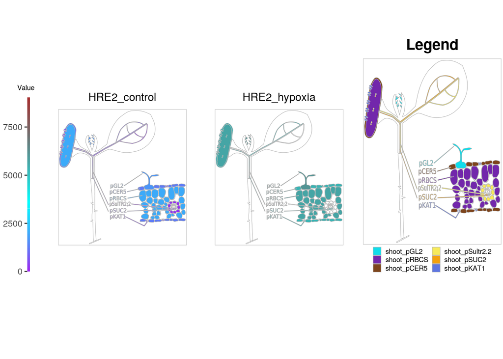

Figure 4 Spatial heatmaps of Arabidopsis shoot. Pre-defined tissue regions are colored by the expression profile of the target gene. The promoter pGL2, pRBCS, pCER5, pSultr2.2, pSUC2, pKAT1 label shoot trichomes, shoot photosynthetic cell, cotyledon and leaf epidermis, shootbundle sheath, shoot phloem companion cells, Cotyledon and leaf guard cells, respectively.

Figure 4 is the spatial heatmap of gene “HRE2” under control and hypoxia. It is clear that this gene’s exression profiles under control are lower than hypoxia across all the 5 tissues (pGL2, pRBCS, pCER5, pSUC2, pKAT1). Therefore, it can be hypothesised that hypoxia induces over-expression of “HRE2” across the 5 tissues and thus “HRE2” might be an important factor for Arabidopsis shoot to cope with hypoxia stress. The tissue pSultr2.2 is blank under hypoxia due to unavailability of its data under hypoxia in the data matrix.

# 4 Matrix Heatmaps

The Matrix Heatmap is designed to supplement the core feature of spatial heatmap. It displays the target gene in the context of corresponding gene network module, so there is a process of gene modules identification.

**Adjacency Matrix and Module Identification**

The modules are identified by `adj_mod`. It first computes an adjacency matrix on the gene expression matrix then hierarchically clusters the adjacency matrix by using WGCNA (Langfelder and Horvath 2008) and flashClust (Langfelder and Horvath 2012). The clutersing includes 4 alternative sensitivity levels (ds=0, 1, 2, or 3). From 3 to 0, the sensitivity decreases and results in less modules with larger sizes. Since the interactive network functionality performs better on smaller modules, only ds of 3 and 2 are used. There are two additional parameters for module identification: signed and unsinged. The “signed” means both positive and negative adjacency between genes are used while the “unsigned” takes the absolute values of negative adjacency.

The function `adj_mod` returns a list containing an adjacency matrix and a data frame of module assignment. It is domenstrated on the Arabidopsis Shoot data.

```r
adj.mod <- adj_mod(se=se.fil.sh, type="signed", minSize=15, dir=NULL)
```

The adjacency matrix is a measure of co-expression similarity between genes, where larger value denotes more similarity.

```r
adj.mod[['adj']][1:3, 1:3]
```

```
##           ndhA      petL      psaJ
## ndhA 1.0000000 0.5374043 0.6088355
## petL 0.5374043 1.0000000 0.7779227
## psaJ 0.6088355 0.7779227 1.0000000
```

The module assignment is a data frame. The first column is ds=2 while the second is ds=3. The numbers in each column are module labels with “0” meaning genes not assigned to any modules.

```r
adj.mod[['mod']][1:3, ]
```

```
##      2 3
## ndhA 1 0
## petL 1 0
## psaJ 1 0
```

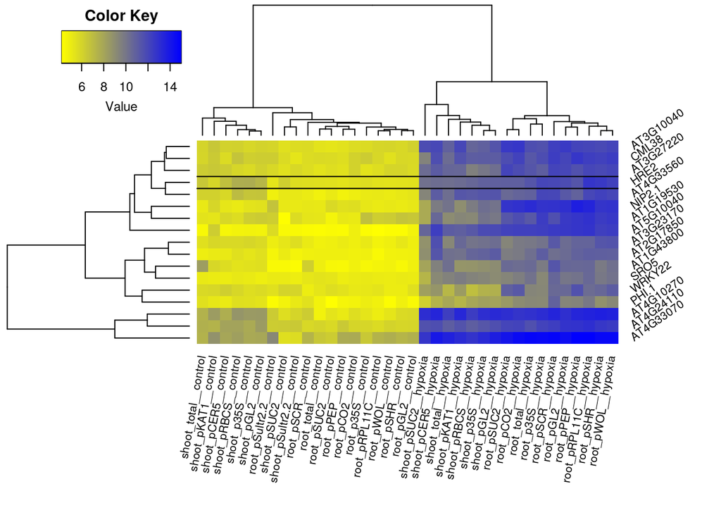

Figure 5 Matrix Heatmap. Rows are genes and columns are samples. The input gene is tagged by 2 black lines.

```r
matrix_hm(geneID="HRE2", se=se.fil.sh, adj.mod=adj.mod, ds="3", scale="no", angleCol=80, angleRow=35, cexRow=0.8, cexCol=0.8, margin=c(10, 6), static=TRUE, arg.lis1=list(offsetRow=0.1, offsetCol=0.1))
```

In Figure 5, the target gene is displayed in the gene module it belongs to, which is indicated by 2 black lines. The rows and columns are sorted by hierarchical clustering dendrograms. The expression matrix of this module is visualised without being scaled (`scale="no"`). It can be seen that the expression levels of this module is overall much higher in hypoxia than control, and therefore it could potentially be used to infer the hypoxia response mechanism in Arabidopsis.

# 5 Network Graphs

The same target gene and module from matrix heatmap can also be displayed as a network. Similarly, the network can be dispayed in static or interactive mode.

Setting `static=TRUE` launches the static network. In Figure 6 Nodes are genes and edges are adjacencies between genes. The thicker edge denotes higher adjacency (co-expression similarity) while larger node indicates higher gene connectivity (sum of a gene’s adjacency with all its direct neighbours). The target gene is labeled by “_selected“.

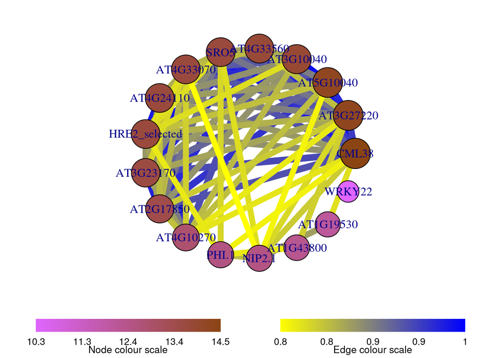

Figure 6 Static network. Node size denotes gene connectivity while edge thickness stands for co-expression similarity.

```r
network(geneID="HRE2", se=se.fil.sh, ann=NULL, adj.mod=adj.mod, ds="3", adj.min=0.75, con.min=0, vertex.label.cex=1.2, vertex.cex=2, static=TRUE)
```

Setting `static=FALSE` launches the interactive network. There is an interactive color bar to denote gene connectivity. The color ingredients must only be separated by comma, e.g. “yellow,black,purple”, which means gene connectivity increases from yellow to purple. If too many edges (e.g.: > 300) are displayed, the network could get stuck. So the “Input an adjacency threshold to display the adjacency network.” option sets a threthold to filter out weak edges. If not too many edges retained (e.g.: < 300), users can check “Yes” under “Display or not?”, then the network would be responsive smoothly. To maintain acceptable performance, users are advised to choose a stringent threshold (e.g. 0.9) initially, then decrease the value gradually. The interactive feature allows users to zoom in and out, or drag a gene around. All the gene IDs in the network module are listed in “Select by id” in decreasing order according to gene connectivity. Same with static mode, the target gene ID is appended “_selected“.

If gene annotation is available in “rowData” slot and provided to ‘ann’, the annotation is seen by mousing over a node. In this example, “Target.Description” in “rowData” is provided to “ann”.

```r
network(geneID="HRE2", se=se.fil.sh, ann='Target.Description', adj.mod=adj.mod, adj.min=0.75, con.min=0, vertex.label.cex=1.2, vertex.cex=2, static=FALSE)
```

# 6 Shiny App

All the above functionality (spatial heatmap, interactive matrix heatmap, interactive network) is also combined into a web-browser based [Shiny App](https://shiny.rstudio.com/), which takes advantage of the computational power of R and interactivity of the web. The main benefits of the Shiny App is combine all the utities in one interface and increase interactivity. On the left of this app is the menu. It includes pre-formatted ready-to-use examples, options to upload formatted data matrix and SVG images, and instruction to use this app. On the right is the interactive interfacce, including Data Matrix, Spatial Heatmap, Matrix Heatmap, and Network. To use interactive features, there are paramters on the left menu to operate. Upon launched, the app automatically displays a pre-formatted example. A good practice to use this app is to follow steps in the menu rather than skipping steps. If unexpectation happens, the app webpage should be refreshed.

This app is launched by the function `shiny_all` without any parameters. Figure 7 is the screenshot of Spatial Heatmap.

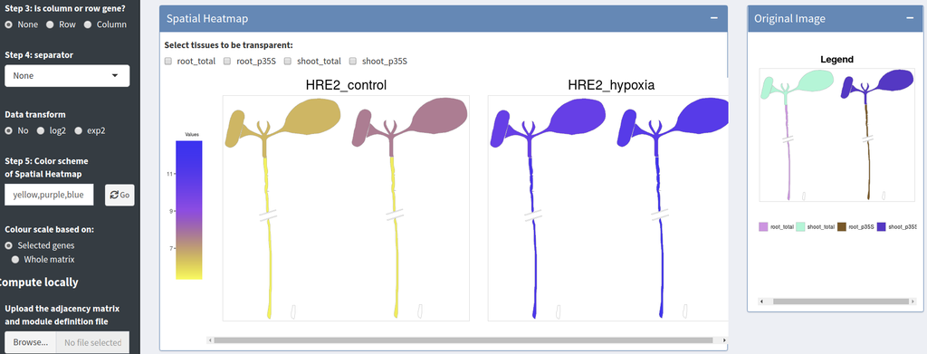

Figure 7 The snapshot of Shiny App. Left is the menu and right is the Spatial Heatmap.

```r
shiny_all()
```

The data matrix to upload is a data frame and can be obtained by setting a directory path to `dir` in function `filter_data`. A directory “local_mode_result/” is automatically created in the provided path, and the filtered data matrix is written to “local_mode_result/processed_data.txt” with column names in the syntax “sample__condition“, which is a tab-separated file. If users want to see annotation by mousing over a node in the network, then the column of gene annotation in “rowData” slot should be provided to `ann`, and the annotation is appended to the last column in “processed_data.txt”.

For example, in `filter_data`, setting `dir='./'` (current working directory) will output the filtered data matrix in “./local_mode_result/processed_data.txt”, and setting `ann="Target.Description"` appends the annotation from `rowData` slot to the last column of “processed_data.txt”, which is ready to upload to the app.

```r
se.fil.sh <- filter_data(se=se.aggr.sh, ann="Target.Description", sam.factor='samples', con.factor='conditions', pOA=c(0.03, 6), CV=c(0.30, 100), dir='./')
```

# 7 Supplement

To plot spatial heatmaps, a pair of formatted data matrix and SVG images are required. The most important step is to format data matrix and SVG image so that the values in data matrix are mapped to polygons in SVG image as expected. The plotting algorithm maps values from the data matrix onto SVG image according to sample names, so only samples with identcial names between the matrix and SVG are colored. The SVG images can be downloaded from the SVG repository or created by following the step-by-step [SVG tutorial](https://jianhaizhang.github.io/SVG_tutorial_file/), which is based on [Inkscape](https://inkscape.org/).

**SVG repository**

To make it user-friendly, an [SVG repository](https://github.com/jianhaizhang/SVG_tutorial_file/tree/master/svg_repo/ebi_trans) across different species is created, where more SVG images will be added in future. These SVG templates are modified from [EBI Gene Expression Group](https://github.com/ebi-gene-expression-group/anatomogram/tree/master/src/svg) to be compatible with spatialHeatmap and are ready to use. If the target SVG image is available in this reposiroty, users only need to download it and set tissue ids. Otherwise, users can follow the step-by-step [SVG tutorial](https://jianhaizhang.github.io/SVG_tutorial_file/) to create custom SVG images.

To plot spatial heatmaps using data from the [Expression Atlas-EMBL-EBI](https://www.ebi.ac.uk/gxa/home) or [GEO](https://www.ncbi.nlm.nih.gov/geo/), first download an SVG image from the SVG repository and a gene exppression data acquired from at least one tissue in the SVG image, then format the data matrix and SVG image.

In the following, the detailed plotting procedure is explained on the Human Brain example only, since other examples are plotted similarly.

## 7.1 Download SVG Image and Data Matrix

```r
all.hum <- searchAtlasExperiments(properties="cerebellum", species="Homo sapiens")
```

Check the results and select one study conducted in at least one tissue in the downloaded SVG image. In this example, the experiment “E-GEOD-67196” is selected, since the data is measured in cerebellum and frontal cortex that are represented in the SVG image, which is an RNA-seq analysis of the 2 tissues from normal and amyotrophic lateral sclerosis (ALS) disease (Prudencio et al. 2015).

```r
all.hum[2, ]
```

```
## DataFrame with 1 row and 4 columns
##      Accession      Species                  Type
##    <character>  <character>           <character>
## 1 E-GEOD-67196 Homo sapiens RNA-seq of coding RNA
##                                                                                                                                   Title
##                                                                                                                             <character>
## 1 Transcription profiling by high throughput sequencing of cerebellum and frontal cortex from patients of amyotrophic lateral sclerosis
```

```r
rse.hum <- getAtlasData('E-GEOD-67196')[[1]][[1]]
```

```
##  ftp://ftp.ebi.ac.uk/pub/databases/microarray/data/atlas/experiments/E-GEOD-67196/E-GEOD-67196-atlasExperimentSummary.Rdata
```

```
## Successfully downloaded experiment summary object for E-GEOD-67196
```

```r
assay(rse.hum)[1:3, 1:3]
```

```
##                 SRR1927019 SRR1927020 SRR1927021
## ENSG00000000003        137         54        266
## ENSG00000000005          0          1          0
## ENSG00000000419        285        117        430
```

## 7.2 Format the Data Matrix

Formatting the data matrix is essentially define replicates of tissues and conditions, and this is carried out by a targets file (a data frame of column metadata) with at least 2 columns specifying sample and condition replicates respectively. The data matrix with rows and columns being genes and sample/conditions respectively should be in the form of “SummarizedExperiment” (Morgan et al. 2018). The “colData” slot contains the a targetes file, while the “rowData” slot is not required for plotting spatial heatmaps.

**Requirements on the targets file**

The data accessed with function `getAtlasData` is raw count matrix is in form of “RangedSummarizedExperiment”. The “colData” slot contains replicates of tissues and conditions and should be used to make a targets file, which mainly involves using abbreviations to replace long phrases, using preffered tissue or condition names.

The formatted targets file is available in this package. The “organism_part” and “disease” column describes tissue and condition replicates respectively. For successful plotting, the 2 tissues cerebellum and frontal_cortex must be identical with respective tissue ids in the downloaded “homo_sapiens.brain.svg”.

```r
hum.pa <- system.file('extdata/shinyApp/example/target_human.txt', package='spatialHeatmap')
target.hum <- read.table(hum.pa, header=TRUE, row.names=1, sep='\t')
```

```r
target.hum[c(1:3, 41:42), 4:5]
```

```
##             organism_part disease
## SRR1927019     cerebellum     ALS
## SRR1927020 frontal_cortex     ALS
## SRR1927021     cerebellum     ALS
## SRR1927059     cerebellum  normal
## SRR1927060 frontal_cortex  normal
```

The targets file needs to be added to “colData” slot as a “DataFrame” class.

```r
colData(rse.hum) <- DataFrame(target.hum)
```

For users with little R expertise, if the gene expression matrix comes as a data frame, it should be placed into “SummarizedExperiment” before proceeding to next step. An example is shown below by borrowing a data frame from the brain data.

Borrow a data matrix.

```r
df <- assay(rse.hum); df[1:2, 1:3]
```

```
##                 SRR1927019 SRR1927020 SRR1927021
## ENSG00000000003        137         54        266
## ENSG00000000005          0          1          0
```

Place the data matrix and targets file (target.hum) into “SummarizedExperiment”. The “rowData” slot is optional.

```r
rse.hum <- SummarizedExperiment(assay=df, colData=target.hum, rowData=NULL)
```

**Pre-process the data matrix**

It is optional to pre-process the data matrix for plotting spatial heatmaps as long as the format is right. However, as a convention the transcriptome data matrix is always pre-processed before downstream analysis, including normalising, replicates aggregating, filtering. The normalising function `norm_data` builds on normalisation methods of `calcNormFactors` in edgeR (McCarthy et al. 2012), and `estimateSizeFactors`, `varianceStabilizingTransformation`, `rlog` in DESeq2 (Love, Huber, and Anders 2014). In this example, the raw count matrix is normalised with `estimateSizeFactors` (type=‘ratio’) and converted to log2 unit.

```r
se.nor.hum <- norm_data(se=rse.hum, method.norm='ratio', data.trans='log2')
```

To aggregate replicates, the sample (organism_part) and condition (disease) column in “colData” slot need to be specified in function `aggr_rep`. This function concatenates sample and condition replicates in the targets file with a “double underscore” and treat them as sample__condition replicates for aggregating. For example, in the above targets file, each of the 2 samples cerebellum and frontal_cortex is concatenated with each of the 2 conditions ALS and normal by “__" to make 4 sample__condition replicates cerebellum__ALS, cerebellum__normal, frontal_cortex__ALS, frontal_cortex__normal. The sample__condition replicates can be aggregated by mean or median. Here mean is chosen.

```r
se.aggr.hum <- aggr_rep(se=se.nor.hum, sam.factor='organism_part', con.factor='disease', aggr='mean')
```

The concatenated sample__conditions are the column names of the output data matrix. In downstream spatial heatmap plotting, the “double underscore” is indispensable as it is the separator for the algorithm to recognise samples and conditions.

```r
assay(se.aggr.hum)[49939:49941, ]
```

Table 3 Aggregated data matrix in Human Brain example. The column names are concatenated tissues and conditions by a “__“.

|  | cerebellum__ALS | frontal_cortex__ALS | cerebellum__normal | frontal_cortex__normal |
| --- | --- | --- | --- | --- |
| ENSG00000268433 | 5.3240638 | 0.3419665 | 3.478074 | 0.1340332 |
| ENSG00000268434 | 0.0000000 | 0.0000000 | 0.000000 | 0.0000000 |
| ENSG00000268438 | 0.7501421 | 0.2093615 | 1.036595 | 0.0000000 |

Genes with low expression level and low variantion are always filtered. In this example, genes with expression values larger than 5 in at least 1% of all samples (pOA=c(0.01, 5)), and with coefficient of variance (CV) between 0.30 and 100 (CV=c(0.30, 100)) are retained.

```r
se.fil.hum <- filter_data(se=se.aggr.hum, sam.factor='organism_part', con.factor='disease', pOA=c(0.01, 5), CV=c(0.3, 100), dir=NULL)
```

## 7.3 Format The SVG Image

Spatial heatmap plotting also requires the SVG image is formatted in a specific way by using [Inkscape](https://inkscape.org/). Figure 8 the downloaded SVG image opened in Inkscape, tissues are represented by paths and labeled by ids.

**SVG format requirements**

[figure not shown]

Figure 8 The human brain SVG image opened in Inkscape. Every tissue is labeled by a unique “id”.

The formatted SVG image is accessible in this package and shown in Figure 9. Colours are only used to label target tissues for easy identification.

```r
svg.hum <- system.file("extdata/shinyApp/example", "homo_sapiens.brain.svg", package="spatialHeatmap")
```

[figure not shown]

Figure 9 Formatted brain SVG image. Target tissues “frontal cortex” and “cerebellum” are labelled by lightblue and yellow for easy identification.

## 7.4 Plot spatial heatmaps

With the formatted data matrix and SVG image, the spatial heatmap is plotted with function `spatial_hm`, which is shown in Figure 1.

```r
spatial_hm(svg.path=svg.hum, se=se.fil.hum, ID='ENSG00000268433', col.com=c("yellow", "blue", "purple"), width=1, height=0.5, sub.title.size=11, layout="gene", ncol=2, tis.trans=NULL, sam.legend='identical', line.size=0.2, line.color='grey70', legend.position=c(0.5, -0.15), legend.nrow=1)
```

```r
# Version Informaion

sessionInfo()
```

```
## R Under development (unstable) (2020-04-16 r78240)
## Platform: x86_64-pc-linux-gnu (64-bit)
## Running under: Debian GNU/Linux 9 (stretch)
##
## Matrix products: default
## BLAS:   /usr/lib/libblas/libblas.so.3.7.0
## LAPACK: /usr/local/lib/R-devel/lib/R/lib/libRlapack.so
##
## locale:
##  [1] LC_CTYPE=en_US.UTF-8       LC_NUMERIC=C
##  [3] LC_TIME=en_US.UTF-8        LC_COLLATE=en_US.UTF-8
##  [5] LC_MONETARY=en_US.UTF-8    LC_MESSAGES=en_US.UTF-8
##  [7] LC_PAPER=en_US.UTF-8       LC_NAME=C
##  [9] LC_ADDRESS=C               LC_TELEPHONE=C
## [11] LC_MEASUREMENT=en_US.UTF-8 LC_IDENTIFICATION=C
```

[output cut: 56 more lines]

# 8 Funding

This project has been funded by NSF awards: [PGRP-1546879](https://www.nsf.gov/awardsearch/showAward?AWD_ID=1546879&HistoricalAwards=false), [PGRP-1810468](https://www.nsf.gov/awardsearch/showAward?AWD_ID=1810468), [PGRP-1936492](https://www.nsf.gov/awardsearch/showAward?AWD_ID=1936492&HistoricalAwards=false).

# References

Cardoso-Moreira, Margarida, Jean Halbert, Delphine Valloton, Britta Velten, Chunyan Chen, Yi Shao, Angélica Liechti, et al. 2019. “Gene Expression Across Mammalian Organ Development.” *Nature* 571 (7766): 505–9.

Chang, Winston, and Barbara Borges Ribeiro. 2018. *Shinydashboard: Create Dashboards with ’Shiny’*. https://CRAN.R-project.org/package=shinydashboard.

Chang, Winston, Joe Cheng, JJ Allaire, Yihui Xie, and Jonathan McPherson. n.d. *Shiny: Web Application Framework for R*. https://CRAN.R-project.org/package=shiny.

Davis, Sean, and Paul Meltzer. 2007. “GEOquery: A Bridge Between the Gene Expression Omnibus (Geo) and Bioconductor.” *Bioinformatics* 14: 1846–7.

Gautier, Laurent, Leslie Cope, Benjamin M. Bolstad, and Rafael A. Irizarry. 2004. “Affy—analysis of Affymetrix Genechip Data at the Probe Level.” *Bioinformatics* 20 (3). Oxford, UK: Oxford University Press: 307–15. doi:10.1093/bioinformatics/btg405.

Keays, Maria. 2019. *ExpressionAtlas: Download Datasets from Embl-Ebi Expression Atlas*.

Langfelder, Peter, and Steve Horvath. 2008. “WGCNA: An R Package for Weighted Correlation Network Analysis.” *BMC Bioinformatics* 9 (December): 559.

———. 2012. “Fast R Functions for Robust Correlations and Hierarchical Clustering.” *Journal of Statistical Software* 46 (11): 1–17. http://www.jstatsoft.org/v46/i11/.

Love, Michael I., Wolfgang Huber, and Simon Anders. 2014. “Moderated Estimation of Fold Change and Dispersion for Rna-Seq Data with Deseq2.” *Genome Biology* 15 (12): 550. doi:10.1186/s13059-014-0550-8.

Maag, Jesper L V. 2018. “Gganatogram: An R Package for Modular Visualisation of Anatograms and Tissues Based on Ggplot2.” *F1000Res.* 7 (September): 1576.

McCarthy, Davis J., Chen, Yunshun, Smyth, and Gordon K. 2012. “Differential Expression Analysis of Multifactor Rna-Seq Experiments with Respect to Biological Variation.” *Nucleic Acids Research* 40 (10): 4288–97.

Merkin, Jason, Caitlin Russell, Ping Chen, and Christopher B Burge. 2012. “Evolutionary Dynamics of Gene and Isoform Regulation in Mammalian Tissues.” *Science* 338 (6114): 1593–9.

Morgan, Martin, Valerie Obenchain, Jim Hester, and Hervé Pagès. 2018. *SummarizedExperiment: SummarizedExperiment Container*.

Muschelli, John, Elizabeth Sweeney, and Ciprian Crainiceanu. 2014. “BrainR: Interactive 3 and 4D Images of High Resolution Neuroimage Data.” *R J.* 6 (1): 41–48.

Mustroph, Angelika, M Eugenia Zanetti, Charles J H Jang, Hans E Holtan, Peter P Repetti, David W Galbraith, Thomas Girke, and Julia Bailey-Serres. 2009. “Profiling Translatomes of Discrete Cell Populations Resolves Altered Cellular Priorities During Hypoxia in Arabidopsis.” *Proc Natl Acad Sci U S A* 106 (44): 18843–8.

Papatheodorou, Irene, Nuno A Fonseca, Maria Keays, Y Amy Tang, Elisabet Barrera, Wojciech Bazant, Melissa Burke, et al. 2018. “Expression Atlas: gene and protein expression across multiple studies and organisms.” *Nucleic Acids Res.* 46 (D1): D246–D251. doi:10.1093/nar/gkx1158.

Prudencio, Mercedes, Veronique V Belzil, Ranjan Batra, Christian A Ross, Tania F Gendron, Luc J Pregent, Melissa E Murray, et al. 2015. “Distinct Brain Transcriptome Profiles in C9orf72-Associated and Sporadic ALS.” *Nat. Neurosci.* 18 (8): 1175–82.

Waese, Jamie, Jim Fan, Asher Pasha, Hans Yu, Geoffrey Fucile, Ruian Shi, Matthew Cumming, et al. 2017. “EPlant: Visualizing and Exploring Multiple Levels of Data for Hypothesis Generation in Plant Biology.” *Plant Cell* 29 (8): 1806–21.

Winter, Debbie, Ben Vinegar, Hardeep Nahal, Ron Ammar, Greg V Wilson, and Nicholas J Provart. 2007. “An ‘Electronic Fluorescent Pictograph’ Browser for Exploring and Analyzing Large-Scale Biological Data Sets.” *PLoS One* 2 (8): e718.